# Removing density from exotic dataset

Lia Ossanna

10/31/2021

# Introduction

- Previously, I had combined the response variables of biomass, cover, and density into one dataset for analysis. Originally (in 0421) I had them separate, but wanted to combine them for higher number of comparisons in each moderator level, so I switched to combining everything into one dataset.
- To prevent non-independence, I kept only 1 response variable for any given comparison or set of plants being measured (some measurements were from subsets of larger groups, but still included some of the same individuals, and thus are not independent).
  - Priority of data to preserve was biomass > cover > density.
    - With the exception of Beckstead 2004, which was a mistake and exotic density was used over biomass; that is corrected in this analysis.
- However, I questioned if density on a per-plot basis was actually similar to biomass and cover, because as plants become more abundant, individuals could grow larger and thus density would decrease.
- All analysis is done on full datasets, without outlier removal.

# Summary

- For the originally combined exotic dataset (referred to as 0621 `ex`), density does not respond in the same way as biomass and cover, which is what this document will show.
- A new dataset (1021 `ex`) was constructed as follows:
  - Originally, the response variable that yielded the most comparisons was used. Here, biomass and cover were prioritized over density (biomass > cover), so when there was more than one response variable, I always chose biomass or cover over density, even if it yielded fewer comparisons.
  - Comparisons that only had density as a response variable were also removed.
- For the native dataset, all three response variables responded the same way to treatment (biomass, density, and cover were all insignificant), so nothing needs to be changed for that analysis.
- Dataset was constructed as follows:
  - Response variable that yielded the most comparisons was used.
  - Preference of biomass > cover > density.

# Setup

- Applies to both 0621 and 1021 analyses.
- Load other data must be separate, because `all.1res`, `biomass`, `cover`, `raw` objects are overwritten (this was to save time on changing names of all the objects).

```r
library(tidyverse)
library(readxl)
library(metafor)

# Functions ---------------------------------------------------------------

single.mod.cat <- function(dat, var, dat.mv, dat.mv.var, h) {
  print(dat.mv.var)
  print(noquote(paste("QM/QT =", dat.mv.var[["QM"]] / sum(dat.mv.var[["QE"]], dat.mv.var[["QM"]]))))

  n.forest <- count(dat, !!sym(var))
  colnames(n.forest) <- c("moderator", "n")
  n.forest$end <- rep(")", dim(n.forest)[1])
  n.forest$n <- paste(n.forest$n, n.forest$end, sep = "")
  n.forest$start <- rep("(n = ", dim(n.forest)[1])
  n.forest$n <- paste(n.forest$start, n.forest$n)
  n.forest$var_col <- paste(n.forest$moderator, n.forest$n)
  n.forest <- n.forest %>%
    filter(!is.na(moderator))
  overall <- paste("Overall (n = ", dat.mv$k, ")", sep = "")

  forest(x = c(dat.mv[[1]], dat.mv.var[[1]]),
         ci.lb = c(dat.mv[[6]], dat.mv.var[[6]]),
         ci.ub = c(dat.mv[[7]], dat.mv.var[[7]]),
         slab = c(overall, n.forest$var_col),
         header = h,
         cex = 0.7)
}
```

# 0621 analysis

## Setup

- Note the Excel spreadsheet tab (`sheet = "screen 3_data (1 res)"`), which is different than the 1021 analysis.

```r
# Load data (0621) --------------------------------------------------------

raw <- read_xlsx("C addition studies.xlsx", sheet = "screen 3_data (1 res)")
raw$plant_apgfs <- paste(raw$plant_anper, raw$plant_gfs, sep = " ")
raw$C_app_tm <- raw$duration_first - raw$duration_last
raw$C_app_ma <- raw$C_app_tm / raw$C_app

# Data wrangling
trt.cntrl.se.sd <- c("biomass_mean_trt", "biomass_SE_trt", "biomass_SD_trt",
                     "biomass_mean_cntrl", "biomass_SE_cntrl", "biomass_SD_cntrl")
to.drop <- c("biomass_SE_trt", "biomass_SE_cntrl", "to_sd_trt", "to_sd_cntrl")
biomass <- raw %>%
  select(!(contains("cover"))) %>%
  select(!contains("density")) %>%
  filter(!is.na(biomass_mean_trt)) %>%
  mutate_at(trt.cntrl.se.sd, as.numeric) %>%
  mutate(to_sd_trt = biomass_SE_trt * sqrt(n_trt)) %>%
  mutate(to_sd_cntrl = biomass_SE_cntrl * sqrt(n_cntrl)) %>%
  mutate(biomass_SD_trt = paste(biomass_SD_trt, to_sd_trt)) %>%
  mutate(biomass_SD_trt = str_remove(biomass_SD_trt, pattern = "NA"), .keep = "unused") %>%
  mutate(biomass_SD_cntrl = paste(biomass_SD_cntrl, to_sd_cntrl)) %>%
  mutate(biomass_SD_cntrl = str_remove(biomass_SD_cntrl, pattern = "NA"), .keep = "unused") %>%
  select(-all_of(to.drop)) %>%
  mutate_at(c("biomass_SD_trt", "biomass_SD_cntrl"), as.numeric) %>%
  rename(mean_trt = biomass_mean_trt) %>%
  rename(mean_cntrl = biomass_mean_cntrl) %>%
  rename(SD_trt = biomass_SD_trt) %>%
  rename(SD_cntrl = biomass_SD_cntrl)
biomass$res <- rep("biomass", nrow(biomass))

trt.cntrl.se.sd <- c("cover_mean_trt", "cover_SE_trt", "cover_SD_trt",
                     "cover_mean_cntrl", "cover_SE_cntrl", "cover_SD_cntrl")
to.drop <- c("cover_SE_trt", "cover_SE_cntrl", "to_sd_trt", "to_sd_cntrl")
cover <- raw %>%
  select(!(contains("biomass"))) %>%
  select(!contains("density")) %>%
  filter(!is.na(cover_mean_cntrl)) %>%
  mutate_at(trt.cntrl.se.sd, as.numeric) %>%
  mutate(to_sd_trt = cover_SE_trt * sqrt(n_trt)) %>%
  mutate(to_sd_cntrl = cover_SE_cntrl * sqrt(n_cntrl)) %>%
  mutate(cover_SD_trt = paste(cover_SD_trt, to_sd_trt)) %>%
  mutate(cover_SD_trt = str_remove(cover_SD_trt, pattern = "NA"), .keep = "unused") %>%
  mutate(cover_SD_cntrl = paste(cover_SD_cntrl, to_sd_cntrl)) %>%
  mutate(cover_SD_cntrl = str_remove(cover_SD_cntrl, pattern = "NA"), .keep = "unused") %>%
  select(-all_of(to.drop)) %>%
  mutate_at(c("cover_SD_trt", "cover_SD_cntrl"), as.numeric)  %>%
  rename(mean_trt = cover_mean_trt) %>%
  rename(mean_cntrl = cover_mean_cntrl) %>%
  rename(SD_trt = cover_SD_trt) %>%
  rename(SD_cntrl = cover_SD_cntrl) # warning because one Burke point is blank (was <1)
cover$res <- rep("cover", nrow(cover))

trt.cntrl.se.sd <- c("density_mean_trt", "density_SE_trt", "density_SD_trt",
                     "density_mean_cntrl", "density_SE_cntrl", "density_SD_cntrl")
to.drop <- c("density_SE_trt", "density_SE_cntrl", "to_sd_trt", "to_sd_cntrl")
density <- raw %>%
  select(!(contains("cover"))) %>%
  select(!contains("biomass")) %>%
  filter(!is.na(density_mean_trt)) %>%
  mutate_at(trt.cntrl.se.sd, as.numeric) %>%
  mutate(to_sd_trt = density_SE_trt * sqrt(n_trt)) %>%
  mutate(to_sd_cntrl = density_SE_cntrl * sqrt(n_cntrl)) %>%
  mutate(density_SD_trt = paste(density_SD_trt, to_sd_trt)) %>%
  mutate(density_SD_trt = str_remove(density_SD_trt, pattern = "NA"), .keep = "unused") %>%
  mutate(density_SD_cntrl = paste(density_SD_cntrl, to_sd_cntrl)) %>%
  mutate(density_SD_cntrl = str_remove(density_SD_cntrl, pattern = "NA"), .keep = "unused") %>%
  select(-all_of(to.drop)) %>%
  filter(density_SD_trt != " NA") %>%
  mutate_at(c("density_SD_trt", "density_SD_cntrl"), as.numeric)  %>%
  rename(mean_trt = density_mean_trt) %>%
  rename(mean_cntrl = density_mean_cntrl) %>%
  rename(SD_trt = density_SD_trt) %>%
  rename(SD_cntrl = density_SD_cntrl)
density$res <- rep("density", nrow(density))

all.1res <- rbind(biomass, cover, density)
```

## Exotic

- Number of comparisons was prioritized first; then order was biomass > cover > density.
- The Beckstead mistake exists in this dataset (a single data point).

```r
# Calculating effect size -------------------------------------------------

ex.0621 <- all.1res %>%
  filter(str_detect(plant_category, "exotic"))

ex.0621 <- escalc(measure = "SMD",
             n1i = n_trt,
             n2i = n_cntrl,
             m1i = mean_trt,
             m2i = mean_cntrl,
             sd1i = SD_trt,
             sd2i = SD_cntrl,
             data = ex.0621)

ex.0621 <- ex.0621 %>%
  filter(!is.na(yi)) # 607 to 519 obs
```

### No moderators

```r
# No moderators -----------------------------------------------------------

ex.0621.mv <- rma.mv(yi = yi,
                V = vi,
                random = ~ 1 | exp_ID / obs_ID,
                data = ex.0621)
```

```r
print(ex.0621.mv)
```

```
##
## Multivariate Meta-Analysis Model (k = 519; method: REML)
##
## Variance Components:
##
##             estim    sqrt  nlvls  fixed         factor
## sigma^2.1  0.3813  0.6175     60     no         exp_ID
## sigma^2.2  0.1452  0.3810    519     no  exp_ID/obs_ID
##
## Test for Heterogeneity:
## Q(df = 518) = 1089.6868, p-val < .0001
##
## Model Results:
##
## estimate      se     zval    pval    ci.lb    ci.ub
##  -0.4632  0.0973  -4.7615  <.0001  -0.6538  -0.2725  ***
##
## ---
## Signif. codes:  0 '***' 0.001 '**' 0.01 '*' 0.05 '.' 0.1 ' ' 1
```

```r
predict(ex.0621.mv)
```

```
##
##     pred     se   ci.lb   ci.ub   pi.lb  pi.ub
##  -0.4632 0.0973 -0.6538 -0.2725 -1.8980 0.9717
```

```r
ex.0621.mv[["QM"]] / sum(ex.0621.mv[["QE"]], ex.0621.mv[["QM"]])
```

```
## [1] 0.02038213
```

```r
# I^2
W <- diag(1 / ex.0621$vi)
X <- model.matrix(ex.0621.mv)
P <- W - W %*% X %*% solve(t(X) %*% W %*% X) %*% t(X) %*% W
100 * sum(ex.0621.mv$sigma2) / (sum(ex.0621.mv$sigma2) + (ex.0621.mv$k-ex.0621.mv$p)/sum(diag(P)))
```

```
## [1] 57.71037
```

```r
100 * ex.0621.mv$sigma2 / (sum(ex.0621.mv$sigma2) + (ex.0621.mv$k-ex.0621.mv$p)/sum(diag(P)))
```

```
## [1] 41.79579 15.91458
```

### Response variable

```r
ex.0621.mv.res <- rma.mv(yi = yi,
                    V = vi,
                    random = ~ 1 | exp_ID / obs_ID,
                    data = ex.0621,
                    mods = ~ factor(res) - 1)
```

```r
h <- c("0621 exotic by response variable (all)", "Estimate [95% CI]")
single.mod.cat(ex.0621, "res", ex.0621.mv, ex.0621.mv.res, h)
```

```
##
## Multivariate Meta-Analysis Model (k = 519; method: REML)
##
## Variance Components:
##
##             estim    sqrt  nlvls  fixed         factor
## sigma^2.1  0.3382  0.5816     60     no         exp_ID
## sigma^2.2  0.1519  0.3897    519     no  exp_ID/obs_ID
##
## Test for Residual Heterogeneity:
## QE(df = 516) = 1075.6174, p-val < .0001
##
## Test of Moderators (coefficients 1:3):
## QM(df = 3) = 28.8299, p-val < .0001
##
## Model Results:
##
##                     estimate      se     zval    pval    ci.lb    ci.ub
## factor(res)biomass   -0.3392  0.1466  -2.3144  0.0206  -0.6265  -0.0519    *
## factor(res)cover     -0.6504  0.1342  -4.8451  <.0001  -0.9136  -0.3873  ***
## factor(res)density   -0.2505  0.1920  -1.3044  0.1921  -0.6269   0.1259
##
## ---
## Signif. codes:  0 '***' 0.001 '**' 0.01 '*' 0.05 '.' 0.1 ' ' 1
##
## [1] QM/QT = 0.0261035021450371
```

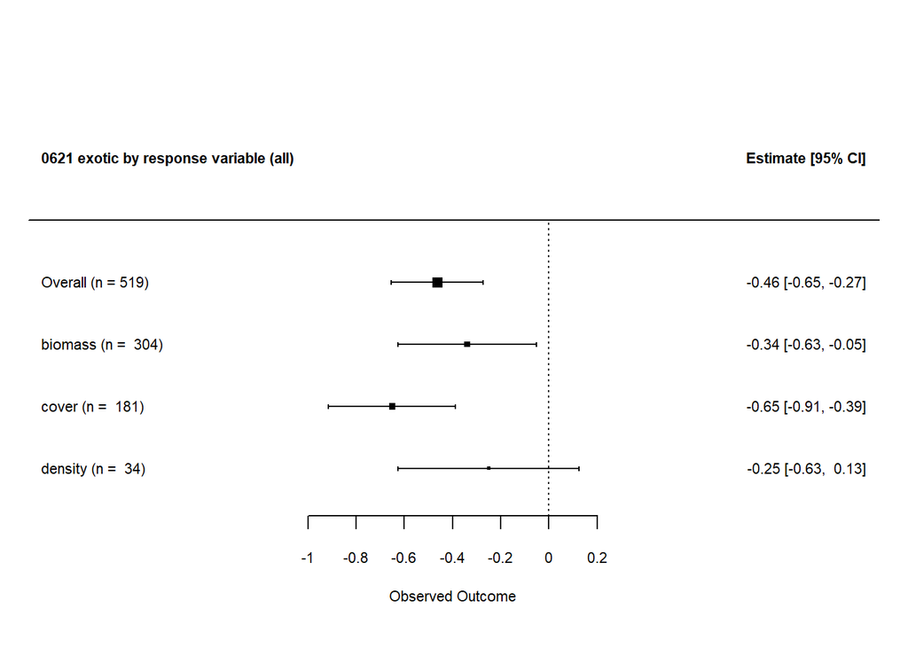

- Density responds differently than biomass and cover.